# Session 6: Homework 3

# 4 Challenge 1: Yield Curve inversion

Every so often, we hear warnings from commentators on the “inverted yield curve” and its predictive power with respect to recessions. An explainer what a [inverted yield curve is can be found here](https://www.reuters.com/article/us-usa-economy-yieldcurve-explainer/explainer-what-is-an-inverted-yield-curve-idUSKBN1O50GA). If you’d rather listen to something, here is a great podcast from [NPR on yield curve indicators](https://www.podbean.com/media/share/dir-4zgj9-6aefd11)

In addition, many articles and commentators think that, e.g., [*Yield curve inversion is viewed as a harbinger of recession*](https://www.bloomberg.com/news/articles/2019-08-14/u-k-yield-curve-inverts-for-first-time-since-financial-crisis). One can always doubt whether inversions are truly a harbinger of recessions, and [use the attached parable on yield curve inversions](https://twitter.com/5_min_macro/status/1161627360946511873).

In our case we looked at US data and used the [FRED database](https://fred.stlouisfed.org/) to download historical yield curve rates, and plot the yield curves since 1999 to see when the yield curves flatten. If you want to know more, a very nice article that explains the [yield curve is and its inversion can be found here](https://fredblog.stlouisfed.org/2018/10/the-data-behind-the-fear-of-yield-curve-inversions/). At the end of this section this graph is reproduced.

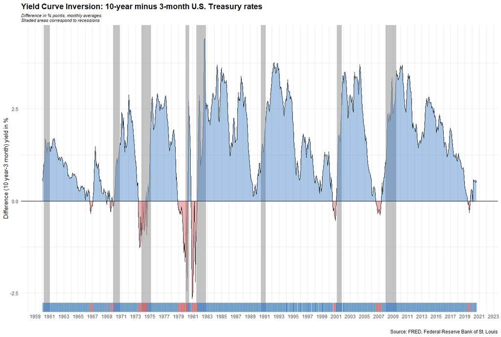

First, we use the `tidyquant` package to download monthly rates for different durations.

```r
# Get a list of FRED codes for US rates and US yield curve; choose monthly frequency
# to see, eg., the 3-month T-bill https://fred.stlouisfed.org/series/TB3MS
tickers <- c('TB3MS', # 3-month Treasury bill (or T-bill)
             'TB6MS', # 6-month
             'GS1',   # 1-year
             'GS2',   # 2-year, etc....
             'GS3',
             'GS5',
             'GS7',
             'GS10',
             'GS20',
             'GS30')  #.... all the way to the 30-year rate

# Turn  FRED codes to human readable variables
myvars <- c('3-Month Treasury Bill',
            '6-Month Treasury Bill',
            '1-Year Treasury Rate',
            '2-Year Treasury Rate',
            '3-Year Treasury Rate',
            '5-Year Treasury Rate',
            '7-Year Treasury Rate',
            '10-Year Treasury Rate',
            '20-Year Treasury Rate',
            '30-Year Treasury Rate')

maturity <- c('3m', '6m', '1y', '2y','3y','5y','7y','10y','20y','30y')

# by default R will sort these maturities alphabetically; but since we want
# to keep them in that exact order, we recast maturity as a factor
# or categorical variable, with the levels defined as we want
maturity <- factor(maturity, levels = maturity)
myvars <- factor(myvars, levels = myvars)

# Create a lookup dataset
mylookup<-data.frame(symbol=tickers,var=myvars, maturity=maturity)
# Take a look:
mylookup %>%
  knitr::kable()
```

| symbol | var | maturity |
| --- | --- | --- |
| TB3MS | 3-Month Treasury Bill | 3m |
| TB6MS | 6-Month Treasury Bill | 6m |
| GS1 | 1-Year Treasury Rate | 1y |
| GS2 | 2-Year Treasury Rate | 2y |
| GS3 | 3-Year Treasury Rate | 3y |
| GS5 | 5-Year Treasury Rate | 5y |
| GS7 | 7-Year Treasury Rate | 7y |
| GS10 | 10-Year Treasury Rate | 10y |
| GS20 | 20-Year Treasury Rate | 20y |
| GS30 | 30-Year Treasury Rate | 30y |

```r
df <- tickers %>% tidyquant::tq_get(get="economic.data",
                   from="1960-01-01")   # start from January 1960

glimpse(df)
```

```
## Rows: 6,774
## Columns: 3
## $ symbol <chr> "TB3MS", "TB3MS", "TB3MS", "TB3MS", "TB3MS", "TB3MS", "TB3MS...
## $ date   <date> 1960-01-01, 1960-02-01, 1960-03-01, 1960-04-01, 1960-05-01,...
## $ price  <dbl> 4.35, 3.96, 3.31, 3.23, 3.29, 2.46, 2.30, 2.30, 2.48, 2.30, ...
```

Our dataframe `df` has three columns (variables):

- `symbol`: the FRED database ticker symbol
- `date`: already a date object
- `price`: the actual yield on that date

The first thing would be to join this dataframe `df` with the dataframe `mylookup` so we have a more readable version of maturities, durations, etc.

```r
yield_curve <-left_join(df,mylookup,by="symbol")
```

## 4.1 Plotting the yield curve

We will reproduce the following three plots

### 4.1.1 Yields on US rates by duration since 1960

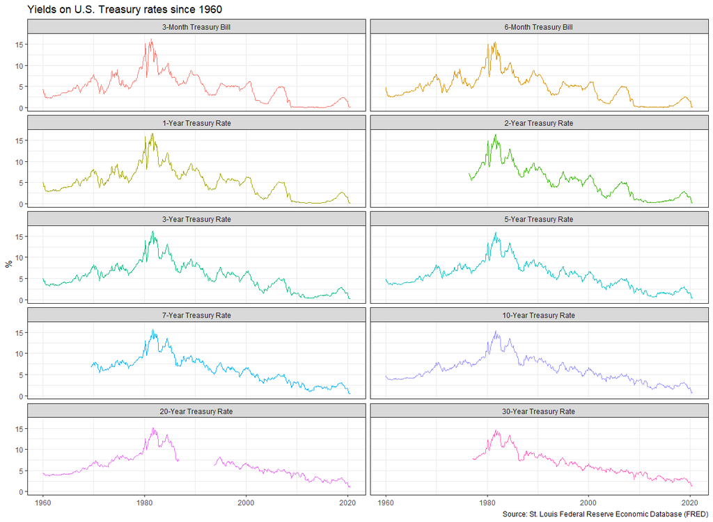

```r
knitr::include_graphics(here::here("images", "yield_curve1.png"), error = FALSE)
```

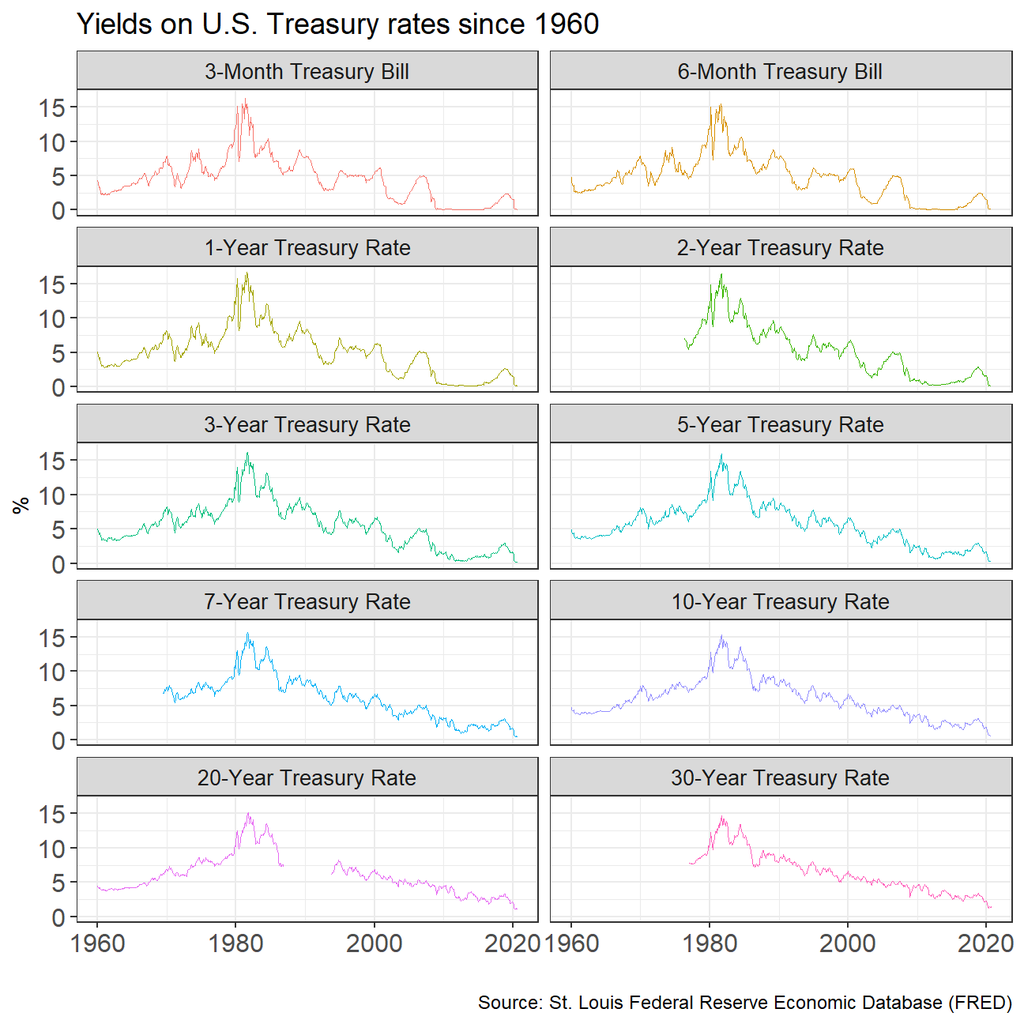

```r
ggplot(yield_curve, aes(x=date,
           y=price,
           colour=var))+
  geom_line(size = 0.3)+
  facet_wrap(~var, ncol = 2)+
  labs(title = "Yields on U.S. Treasury rates since 1960",
         x="",
         y="%",
       caption = "Source: St. Louis Federal Reserve Economic Database (FRED)")+
   theme_bw()+
  theme(
    text = element_text(size=9),
        legend.title = element_blank(),
        legend.position = "none",
        strip.text = element_text(size=10),
        plot.title = element_text(size = 14),
        axis.title = element_text(size=10),
        axis.text = element_text(size = 12),
        plot.caption = element_text(size = 9))+
  NULL
```

### 4.1.2 Monthly yields on US rates by duration since 1999 on a year-by-year basis

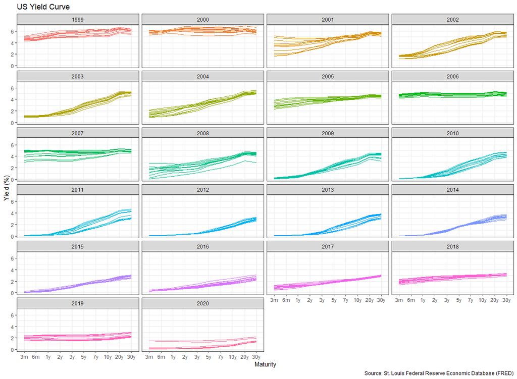

```r
knitr::include_graphics(here::here("images", "yield_curve2.png"), error = FALSE)
```

```r
yield_curve_year <- yield_curve %>%
  mutate(year = year(date), day = day(date), month = month(date), num_maturity = as.integer(maturity)) %>%
  filter (year > 1998, day == 1) %>%
  group_by(month)

yield_curve_year
```

```
## # A tibble: 2,610 x 9
## # Groups:   month [12]
##    symbol date       price var           maturity  year   day month num_maturity
##    <chr>  <date>     <dbl> <fct>         <fct>    <dbl> <int> <dbl>        <int>
##  1 TB3MS  1999-01-01  4.34 3-Month Trea~ 3m        1999     1     1            1
##  2 TB3MS  1999-02-01  4.44 3-Month Trea~ 3m        1999     1     2            1
##  3 TB3MS  1999-03-01  4.44 3-Month Trea~ 3m        1999     1     3            1
##  4 TB3MS  1999-04-01  4.29 3-Month Trea~ 3m        1999     1     4            1
##  5 TB3MS  1999-05-01  4.5  3-Month Trea~ 3m        1999     1     5            1
##  6 TB3MS  1999-06-01  4.57 3-Month Trea~ 3m        1999     1     6            1
##  7 TB3MS  1999-07-01  4.55 3-Month Trea~ 3m        1999     1     7            1
##  8 TB3MS  1999-08-01  4.72 3-Month Trea~ 3m        1999     1     8            1
##  9 TB3MS  1999-09-01  4.68 3-Month Trea~ 3m        1999     1     9            1
## 10 TB3MS  1999-10-01  4.86 3-Month Trea~ 3m        1999     1    10            1
## # ... with 2,600 more rows
```

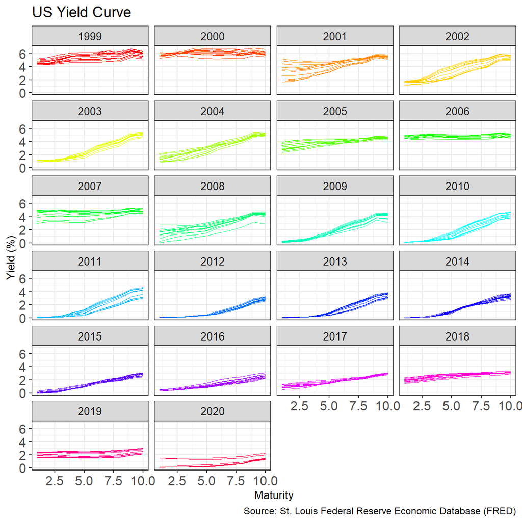

```r
ggplot(yield_curve_year, aes(x=num_maturity,
           y=price, group = month, color = as.factor(year)))+
  geom_line(size = 0.3)+
  facet_wrap(~year, ncol = 4) +
  scale_discrete_manual("colour", values = rainbow(22)) +
  labs(title = "US Yield Curve",
         x="Maturity",
         y="Yield (%)",
       caption = "Source: St. Louis Federal Reserve Economic Database (FRED)")+
   theme_bw() +
  theme(
    text = element_text(size=9),
        strip.text = element_text(size=10),
        plot.title = element_text(size = 14),
        axis.title = element_text(size=10),
        axis.text = element_text(size = 12),
        plot.caption = element_text(size = 9),
    legend.title = element_blank(), legend.position = "none") +
  NULL
```

### 4.1.3 3-month and 10-year yields since 1999

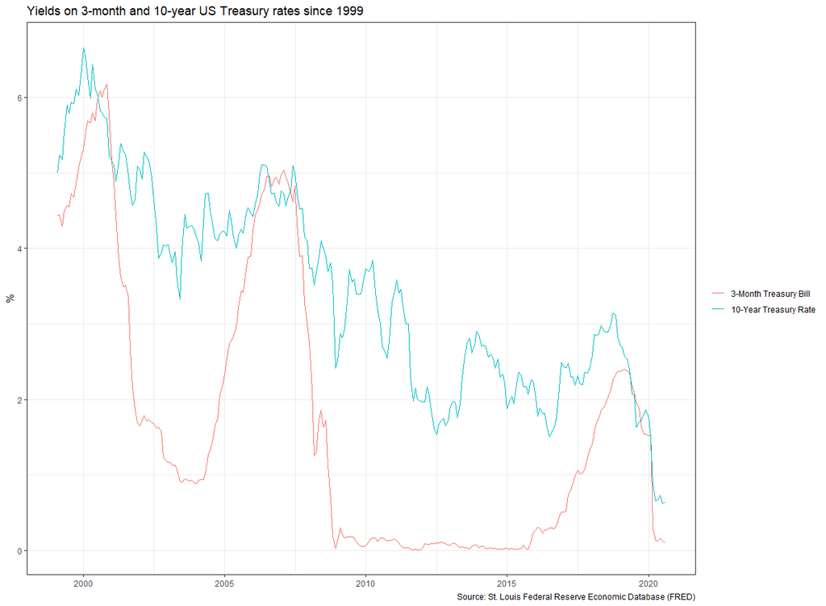

```r
knitr::include_graphics(here::here("images", "yield_curve3.png"), error = FALSE)
```

```r
yield_curve_1999 <- yield_curve %>%
  mutate(year = year(date)) %>%
  filter(year > 1998, var %in% c("3-Month Treasury Bill", "10-Year Treasury Rate"))

yield_curve_1999
```

```
## # A tibble: 522 x 6
##    symbol date       price var                   maturity  year
##    <chr>  <date>     <dbl> <fct>                 <fct>    <dbl>
##  1 TB3MS  1999-01-01  4.34 3-Month Treasury Bill 3m        1999
##  2 TB3MS  1999-02-01  4.44 3-Month Treasury Bill 3m        1999
##  3 TB3MS  1999-03-01  4.44 3-Month Treasury Bill 3m        1999
##  4 TB3MS  1999-04-01  4.29 3-Month Treasury Bill 3m        1999
##  5 TB3MS  1999-05-01  4.5  3-Month Treasury Bill 3m        1999
##  6 TB3MS  1999-06-01  4.57 3-Month Treasury Bill 3m        1999
##  7 TB3MS  1999-07-01  4.55 3-Month Treasury Bill 3m        1999
##  8 TB3MS  1999-08-01  4.72 3-Month Treasury Bill 3m        1999
##  9 TB3MS  1999-09-01  4.68 3-Month Treasury Bill 3m        1999
## 10 TB3MS  1999-10-01  4.86 3-Month Treasury Bill 3m        1999
## # ... with 512 more rows
```

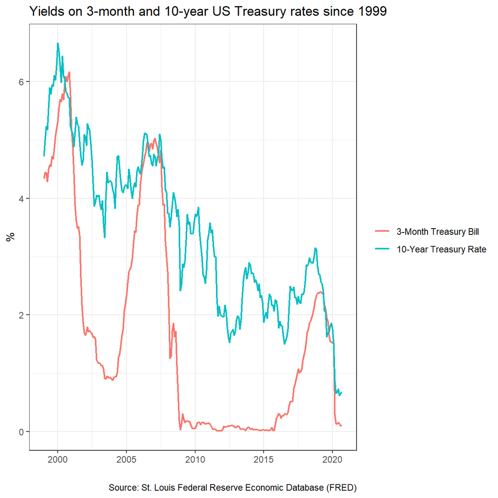

```r
ggplot(yield_curve_1999, aes(x=date,
           y=price, group = maturity, color = var))+
  geom_line(size = 0.8)+
  labs(title = "Yields on 3-month and 10-year US Treasury rates since 1999",
         x="",
         y="%",
       caption = "Source: St. Louis Federal Reserve Economic Database (FRED)")+
  theme_bw() +
  theme(
    legend.title = element_blank()
  ) +
  NULL
```

According to [Wikipedia’s list of recession in the United States](https://en.wikipedia.org/wiki/List_of_recessions_in_the_United_States), since 1999 there have been two recession in the US: between Mar 2001–Nov 2001 and between Dec 2007–June 2009.

The yield curve flattens at both time-points prior to the recession. The yield curve flattening occers when the near term bonds have better yield than longterm bonds, in this case when 3-month offer higher yield than 10-year treasuries.

Can a yield curve flattening really mean a recession is coming in the US? Since 1999, short-term (3 months) yield offered better return than longer term (10 years) debt at three time points, ~2001, ~2008, and again in ~2019.

Besides calculating the spread (10year - 3months), there are a few things we need to do to produce our final plot